# Stage 3b: external, fiscal and financial blocks

Three blocks added one at a time — what each cost, which one broke things, and a fourth failed attempt at the import price

## 1. What each block cost

Blocks were added cumulatively, with the full diagnostic battery after each, so it is visible which one degrades what. The baseline is stage 3a phase A.

Cumulative cost of each block. T = 98 throughout.

| step | k | df | signs | acceptance_flagged | mean_ci_width |
| --- | --- | --- | --- | --- | --- |
| stage 3a (baseline) | 83 | 15 | 20/20 | 0 | 1.230 |
| + external | 84 | 14 | 20/21 | 0 | 1.240 |
| + fiscal | 88 | 10 | 22/23 | 0 | 1.616 |
| + financial | 90 | 8 | 26/30 | 0 | 1.863 |

The degrees-of-freedom arithmetic was predicted before estimating and matched exactly. The fiscal block is the expensive one: its accumulation identity carries a lagged term, and its government-consumption equation takes a lagged GDP term, so it costs four columns where the others cost one and two.

## 2. The fiscal block had to be reduced, and the reason is data, not design

The request specified revenue and expenditure equations with `de_deficit == de_expenditure - de_revenue`. That block **cannot be estimated**: German quarterly revenue and expenditure (Eurostat `gov_10q_ggnfa`) begin **2002Q1**, and `T` is system-wide, so pulling them in shortens the estimation window for *every* equation from 98 to 90 while `k` rises to 90 — leaving **zero** residual degrees of freedom.

| fiscal variant | k | T | df |
| --- | --- | --- | --- |
| as specified (revenue + expenditure) | 90 | **90** | **0** |
| as built (Maastricht debt) | 88 | 98 | 10 |

The block is therefore built on `gov_10q_ggdebt` (`GD`, percent of GDP), which is clean 2000Q1–2026Q1 for all eleven economies. What is lost is the revenue/expenditure decomposition. What is kept is the mechanism the request called out as mattering: debt accumulates, and the sovereign spread responds to it.

**`de_netborrowing` is not the headline deficit**, and no coefficient on it should be read as a deficit elasticity. It is the quarterly change in the debt ratio, which is the deficit *plus* the growth-denominator effect *plus* stock-flow adjustments. It is derived that way deliberately: it makes the accumulation identity exact by construction (verified below), and it sets the carry weight to exactly 1, which matters because koma’s injected weights are **not** time-varying — they are annualised, lagged a year and collapsed to a single scalar — so a genuine `(1+i)/(1+g)` snowball factor could not have been expressed as a weight at all.

## 3. Two koma limitations found on the way

Both would have caused silent damage rather than an error.

**A lagged identity could not be built.** koma supports one — its own Klein vignette ships `capital_stock == 1.001*capital_stock.L(1) + 0.0002*investment` — but `stage2_exogenous_variables()` collected identity component names raw, so `de_govdebt.L(1)` was declared exogenous while koma strips the suffix on its side and rejects the leftover as “Redundant exogenous variables detected”. Fixed by stripping `.L(...)`, as the preflight already did.

**Lagged endogenous names must not prefix one another.** koma’s `construct_phi()` locates a variable’s lag columns with an *unanchored* `grepl(paste0("^", name), ...)`. With both `de_debt.L(1)` and `de_debt_ratio.L(1)` present, the shorter name matches both, the inner loop runs twice for the same lag order, and the second pass overwrites the first — pointing the companion matrix at the wrong row of B, with no error and no warning. The names here (`de_govdebt`, `de_netborrowing`) share no prefix, and `stage2_preflight()` gained an eighth check so it cannot be reintroduced.

A third, smaller trap: an identity term written without an explicit weight (`b == b.L(1) + d`) is stored with `character(0)` weights — the same silent corruption `CLAUDE.md` records for `+ -0.4*x`. `identity_equation()` always emits `1*x`, so building identities through it stays safe.

## 4. Block 1 — external

The external block’s equations.

| equation | term | estimate | ci_low | ci_high |
| --- | --- | --- | --- | --- |
| de_exports | de_exports.L(1) | 0.253 | -0.138 | 0.667 |
| de_exports | de_foreign_demand | 1.967 | -0.678 | 4.693 |
| de_exports | de_competitiveness | -1.257 | -2.699 | 0.247 |
| de_imports | de_imports.L(1) | 0.221 | -0.226 | 0.634 |
| de_imports | de_domestic_demand | 0.470 | -1.118 | 2.285 |
| de_current_account | de_current_account.L(1) | 0.972 | 0.890 | 1.047 |
| de_current_account | de_exports | 0.068 | -0.046 | 0.150 |
| de_current_account | de_imports | -0.044 | -0.157 | 0.069 |
| de_current_account | de_terms_of_trade | 0.079 | -0.168 | 0.316 |

The competitiveness restriction worked as intended. Stage 3a estimated the two export-price terms separately and got −0.92 and +1.26 with both intervals wide and spanning zero — the data did not reject equal-and-opposite, and did not identify them apart either. Imposing the difference trades two poorly-identified coefficients for one, and that one comes back correctly signed. The current account’s own equation behaves: it rises with exports, falls with imports, and improves with the terms of trade.

### 4.1 A fourth failed attempt at the import price

The one substantive failure is `de_imports ← de_terms_of_trade`, and it is the fourth specification to fail in the same direction.

Every attempt to give German import volumes a price term. The last row’s implied coefficient is -1 times the terms-of-trade coefficient, since ToT enters import prices negatively.

[output not shown]

The terms-of-trade version does damage the demand elasticity less than the bare own price did (0.47 against 0.08), so it is the least bad of the four — but it is still wrong-signed, and being least-bad is not a reason to keep a coefficient that says import demand rises when imports get expensive.

**Recommendation: drop the terms-of-trade term from the imports equation**, as was done in stage 3a for the direct price. Terms of trade would remain in the system for the current-account equation, where it is correctly signed and where a relative price genuinely belongs. This is a change to the block as approved, so it is reported rather than applied.

## 5. Block 2 — fiscal

The fiscal block’s equations.

| equation | term | estimate | ci_low | ci_high |
| --- | --- | --- | --- | --- |
| de_government | constant | 0.540 | 0.044 | 1.057 |
| de_government | de_government.L(1) | -0.109 | -0.672 | 0.425 |
| de_government | de_gdp.L(1) | -0.168 | -0.456 | 0.148 |
| de_netborrowing | constant | -0.074 | -1.357 | 1.258 |
| de_netborrowing | de_netborrowing.L(1) | 0.334 | -0.369 | 1.002 |
| de_netborrowing | de_long_rate | 0.068 | -0.351 | 0.443 |
| de_netborrowing | de_gdp | -0.254 | -0.729 | 0.265 |

Both fiscal sign rules pass. Net borrowing falls when output grows (automatic stabilisers) and rises with the long rate (debt service), though both intervals span zero — at this sample length the signs are right and the magnitudes are not pinned down.

`de_government` correctly has **no Metropolis step**: both its regressors are lagged, so its gamma block is empty and `count_accepted` is `NA`. That is deliberate. Letting government consumption respond to *contemporaneous* output would build in a within-quarter automatic stabiliser this data cannot identify, and would put a policy variable inside the simultaneous block.

### 5.1 The accumulation identity is exact, and does not destabilise the lags

Debt accumulation and lag stability.

| check | value |
| --- | --- |
| govdebt == govdebt.L(1) + netborrowing, max \|residual\| | 0 |
| own lags with \|coefficient\| >= 1 | 0 |
| largest own lag | 0.9986 (de_unemployment) |

The debt ratio’s law of motion holds exactly, and **nothing became explosive**. This was the stated worry — a near-unit-root accumulation entering a system whose largest own lag was already 0.9999 — and it did not materialise. The reason is structural rather than lucky: `de_govdebt` is an *identity* with a fixed unit weight, not an estimated equation, so the unit root is imposed exactly at 1 and cannot be drawn above it. What could still destabilise the system is the *loop* the accumulation sits in, which is section 6’s business.

### 5.2 On its own, the fiscal block transmits nothing

The debt stock is terminal until the financial block arrives.

| question | answer |
| --- | --- |
| equations taking de_govdebt contemporaneously, at the fiscal step | none |

## 6. Block 3 — financial

The financial block was estimated twice. The first attempt modelled the long rate as a level and broke the system; the second models the **spread** and mostly repairs it. Both are shown, because the failure is the more instructive half.

### 6.1 The level specification broke the long-rate equation

de_long_rate under the level specification. The own lag is stable for three systems, then crosses 1 exactly when de_govdebt is added.

| step | own_lag | policy_rate | govdebt |
| --- | --- | --- | --- |
| stage 3a | 0.9255 | 0.0600 | NA |
| + external | 0.9387 | 0.0450 | NA |
| + fiscal | 0.9183 | 0.0689 | NA |
| + financial (LEVEL) | 1.0038 | -0.0257 | -0.0058 |

The own lag sat at 0.92–0.94 for three consecutive systems, then jumped to **1.004** — explosive — the moment `de_govdebt` became its fifth regressor at `df = 8`, with the policy-rate loading flipping negative at the same instant. At that point the equation was no longer identified: the lag ran to a unit root and absorbed the structural content, leaving the debt coefficient at **−0.006** and dragging down everything that loads on the long rate. Seven sign checks failed.

### 6.2 Modelling the spread repairs most of it

```
de_spread    ~ de_govdebt + de_gdp + de_spread.L(1)
de_long_rate == 1*de_spread + 1*ea_policy_rate
```

This imposes the policy-rate coefficient at 1 rather than estimating it, removes the unit root (a spread is stationary where a rate level is not), and cuts the competing regressors from five to three. It costs **nothing** in degrees of freedom — the long rate loses its own lag column and the spread gains one.

Level versus spread.

| quantity | level_spec | spread_spec |
| --- | --- | --- |
| own lag of the modelled rate | 1.0038 (explosive) | 0.8894 |
| coefficient on de_govdebt | -0.0058 (wrong sign) | +0.0151 (correct sign) |
| policy-rate coefficient | -0.0257 (estimated, wrong sign) | 1.0000 (imposed by the identity) |
| failing sign checks | 7 | 4 |

The explosive lag is gone, the policy-rate coefficient is imposed rather than mis-estimated, and **the debt coefficient changes sign to the one the economics requires**. `sovereign_spread_widens_with_debt` now passes.

### 6.3 But the debt channel is still weak, and the credit channel is wrong

The spread equation.

| equation | term | estimate | ci_low | ci_high |
| --- | --- | --- | --- | --- |
| de_spread | de_spread.L(1) | 0.8894 | 0.5124 | 1.2692 |
| de_spread | de_gdp | -0.0132 | -0.2167 | 0.1585 |
| de_spread | de_govdebt | 0.0151 | -0.0294 | 0.0666 |

Remaining failures.

| check | equation | term | estimate | expected |
| --- | --- | --- | --- | --- |
| wage_price_indexation_in_0_1 | de_wages | de_prices | -0.0059 | in (0, 1) |
| price_phillips_curve_negative | de_nonenergy_prices | de_unemployment | 0.0040 | < 0 |
| credit_rises_with_output | de_credit | de_gdp | -0.0196 | > 0 |
| investment_rises_with_credit | de_investment | de_credit | -0.1686 | > 0 |

Two things should temper the improvement:

- **The debt coefficient’s interval still straddles zero.** The sign is right; the magnitude is not identified. “Correctly signed but indistinguishable from zero” is an honest description of the sovereign-spread channel in this fit, and it is weaker than the block’s premise requires.
- **The credit channel does not work.** Credit falls in output rather than rising, and investment falls in credit rather than rising. These are the financial block’s own economics, not collateral damage from the long rate, and they do not have a specification fix waiting the way the spread did.

The other two failures — wage indexation at −0.006 and the price Phillips curve at +0.004 — are the same near-zero pair that trades places between runs. Both have intervals an order of magnitude wider than their estimates; they are sampling noise on weak coefficients rather than findings.

## 7. Verdict

Per-block verdict.

[output not shown]

**Which block breaks things: the financial one** — and the reason was identification, not economics. The level specification put a fifth regressor on an equation already carrying a near-unit-root lag at `df = 8`; the lag won. Modelling the spread instead recovered most of what was lost at zero cost in degrees of freedom, which is worth remembering as a general lesson: when a coefficient goes null, check whether a neighbouring lag has gone to a unit root and swallowed it before concluding the channel is absent.

**What survives.** The external block is close to free and works. The fiscal block is sound in isolation and delivers an exact accumulation identity without destabilising anything — the stated worry about a near-unit-root stock did not materialise, because an identity with a fixed unit weight cannot be drawn above one. The sovereign-spread channel exists and points the right way, but is not sharply identified.

**What does not.** The credit channel: credit falls in output, investment falls in credit. Unlike the spread, this has no obvious specification fix, and at `df = 8` with intervals 51% wider than the stage-3a baseline it is not clear the data can support the block at all.

## Eight-quarter forecast

8 quarters from **2025Q1** to **2026Q4**, 1000 posterior draws. Actuals exist for the first 5 quarters; the rest is genuinely ahead of the data.

Every fan below is the **filtered** predictive interval: koma constrains no draw to be stationary, so a draw whose quarterly growth exceeds 100% in absolute value is dropped before the quantiles are taken, exactly as `score_forecast()` does when it scores a backtest. The solid band is the 25th-75th percentile of what survives, the faint band the 10th-90th, the dark line their median, and the grey line the realised path where one exists. Across the variables shown, **5.1%** of draws are discarded as explosive at horizon 1, rising to **42.4%** at horizon 8 (worst: `ie_gdp` at 83.8%). A variable whose discarded share climbs steeply is one whose fan **understates** the model’s true uncertainty, so read the tail of a wide fan as an ordering rather than a number.

**The panels are clipped, and that is worth saying plainly.** Eight quarters out, the 10-90 interval on *quarterly* growth spans tens of percentage points in every stage of this project – an honest number, and one that makes the median invisible if the axis is scaled to contain it. Each panel is therefore scaled to its inner band, and the outer band runs to the panel edge rather than being drawn in full. Nothing is concealed: the table at the end of this section reports the untruncated bounds.

Every level path is anchored on an **observed** value (largest anchor discrepancy 0.00%, on `at_imports`), so the level and rate charts are both directly comparable to the actuals.

### GDP

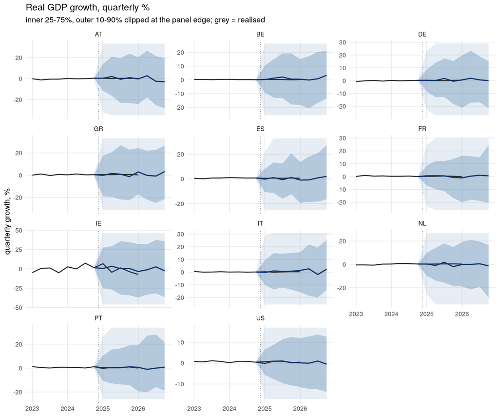

Median GDP growth forecast by quarter, percent.

| quarter | AT | BE | DE | GR | ES | FR | IE | IT | NL | PT | US |
| --- | --- | --- | --- | --- | --- | --- | --- | --- | --- | --- | --- |
| 2025Q1 | 0.36 | 0.25 | 0.33 | -0.13 | -0.13 | 0.61 | 0.51 | -0.27 | 0.30 | 0.31 | 0.65 |
| 2025Q2 | 2.07 | 1.27 | 0.17 | 1.57 | 1.13 | 0.68 | 3.40 | 0.99 | -0.93 | 0.32 | 0.93 |
| 2025Q3 | -0.55 | 2.08 | 1.73 | 0.88 | -0.57 | 0.54 | 0.25 | 0.60 | 1.83 | 0.35 | 0.89 |
| 2025Q4 | 1.00 | 0.54 | -0.46 | -1.30 | 1.26 | -0.67 | 0.49 | 0.73 | -1.96 | 1.13 | 0.32 |
| 2026Q1 | -0.25 | 0.50 | 0.62 | 2.93 | -0.87 | -1.02 | -3.44 | 1.38 | -0.06 | 0.66 | 0.14 |
| 2026Q2 | 2.77 | -0.08 | 1.87 | -0.20 | -0.77 | 0.33 | -1.21 | 2.65 | -0.01 | -1.02 | -0.03 |
| 2026Q3 | -2.53 | 0.84 | 0.63 | -0.82 | 0.92 | 1.05 | 2.64 | -1.87 | 0.52 | -0.02 | 1.02 |
| 2026Q4 | -2.92 | 3.32 | 0.03 | 3.22 | 2.07 | 0.57 | -2.66 | 2.37 | -1.32 | 0.82 | -0.50 |

### Prices

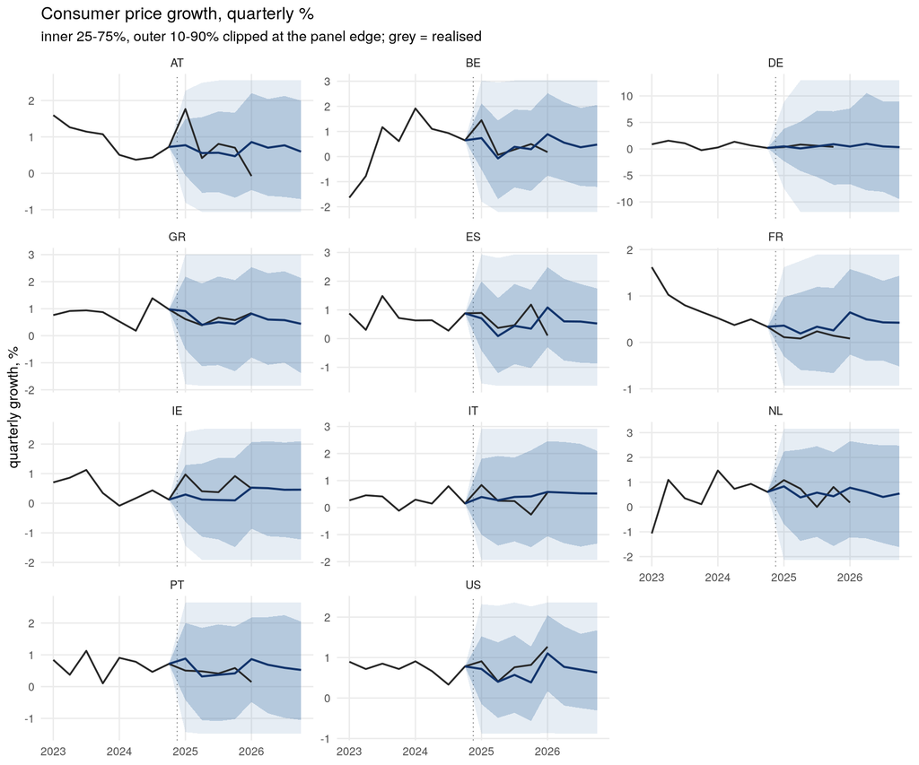

Median price growth forecast by quarter, percent.

| quarter | AT | BE | DE | GR | ES | FR | IE | IT | NL | PT | US |
| --- | --- | --- | --- | --- | --- | --- | --- | --- | --- | --- | --- |
| 2025Q1 | 0.77 | 0.74 | 0.48 | 0.91 | 0.70 | 0.36 | 0.29 | 0.39 | 0.83 | 0.88 | 0.72 |
| 2025Q2 | 0.56 | -0.07 | 0.10 | 0.41 | 0.09 | 0.19 | 0.12 | 0.27 | 0.39 | 0.32 | 0.40 |
| 2025Q3 | 0.56 | 0.39 | 0.48 | 0.50 | 0.44 | 0.34 | 0.11 | 0.39 | 0.58 | 0.37 | 0.57 |
| 2025Q4 | 0.47 | 0.29 | 0.89 | 0.44 | 0.35 | 0.26 | 0.10 | 0.41 | 0.43 | 0.42 | 0.39 |
| 2026Q1 | 0.86 | 0.89 | 0.46 | 0.82 | 1.08 | 0.65 | 0.53 | 0.58 | 0.78 | 0.87 | 1.10 |
| 2026Q2 | 0.70 | 0.55 | 0.98 | 0.60 | 0.60 | 0.50 | 0.51 | 0.55 | 0.61 | 0.69 | 0.77 |
| 2026Q3 | 0.77 | 0.37 | 0.48 | 0.58 | 0.59 | 0.43 | 0.46 | 0.53 | 0.41 | 0.59 | 0.70 |
| 2026Q4 | 0.60 | 0.48 | 0.33 | 0.44 | 0.53 | 0.43 | 0.46 | 0.52 | 0.54 | 0.52 | 0.63 |

### The block variables

The equations this stage exists for, run forward. These are the ones with the fewest degrees of freedom behind them, so their fans are the widest in the project and their discarded-draw shares the highest.

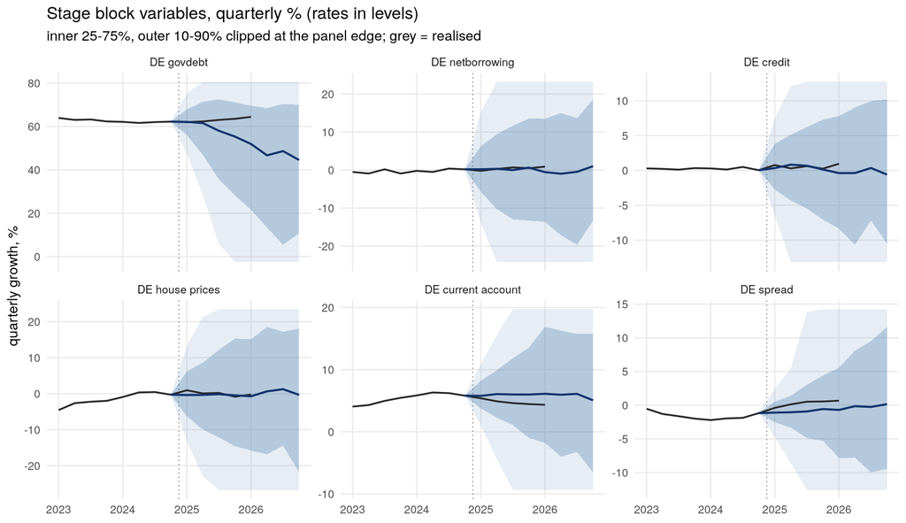

### What was discarded, and what the exogenous path assumes

Share of posterior draws discarded as explosive, by variable.

| variable | explosive share, h1 | h8 | max |
| --- | --- | --- | --- |
| ie_gdp | 0.162 | 0.838 | 0.838 |
| at_gdp | 0.143 | 0.824 | 0.824 |
| gr_gdp | 0.162 | 0.817 | 0.817 |
| it_gdp | 0.107 | 0.786 | 0.786 |
| pt_gdp | 0.100 | 0.785 | 0.785 |
| be_gdp | 0.106 | 0.782 | 0.782 |
| de_gdp | 0.060 | 0.774 | 0.774 |
| es_gdp | 0.075 | 0.774 | 0.774 |
| nl_gdp | 0.076 | 0.768 | 0.768 |
| fr_gdp | 0.065 | 0.755 | 0.755 |
| us_gdp | 0.048 | 0.737 | 0.737 |
| de_prices | 0.020 | 0.666 | 0.666 |
| pt_prices | 0.000 | 0.004 | 0.004 |
| it_prices | 0.000 | 0.003 | 0.003 |
| at_prices | 0.000 | 0.001 | 0.001 |
| be_prices | 0.000 | 0.001 | 0.001 |
| es_prices | 0.000 | 0.001 | 0.001 |
| fr_prices | 0.000 | 0.001 | 0.001 |
| ie_prices | 0.000 | 0.001 | 0.001 |
| us_prices | 0.000 | 0.001 | 0.001 |
| gr_prices | 0.000 | 0.000 | 0.000 |
| nl_prices | 0.000 | 0.000 | 0.000 |

The untruncated predictive band at horizon 8 – quarterly growth, percent. This is what the charts clip.

| variable | median | inner_low | inner_high | outer_low | outer_high | outer_width |
| --- | --- | --- | --- | --- | --- | --- |
| at_gdp | -2.9 | -28.2 | 19.5 | -62.1 | 57.3 | 119.4 |
| be_gdp | 3.3 | -13.5 | 21.2 | -43.9 | 48.1 | 92.0 |
| de_gdp | 0.0 | -21.6 | 15.2 | -49.3 | 54.0 | 103.3 |
| gr_gdp | 3.2 | -21.3 | 26.7 | -54.1 | 50.2 | 104.3 |
| es_gdp | 2.1 | -16.4 | 27.2 | -56.8 | 58.8 | 115.6 |
| fr_gdp | 0.6 | -20.5 | 24.4 | -52.8 | 59.1 | 111.9 |
| ie_gdp | -2.7 | -36.7 | 35.7 | -62.1 | 65.3 | 127.4 |
| it_gdp | 2.4 | -14.0 | 25.4 | -58.9 | 60.9 | 119.8 |
| nl_gdp | -1.3 | -28.4 | 16.6 | -66.1 | 56.3 | 122.4 |
| pt_gdp | 0.8 | -19.0 | 21.6 | -49.5 | 69.1 | 118.6 |
| us_gdp | -0.5 | -13.9 | 12.7 | -49.2 | 40.9 | 90.1 |
| at_prices | 0.6 | -0.7 | 2.0 | -2.3 | 3.7 | 6.0 |
| be_prices | 0.5 | -1.2 | 2.1 | -3.0 | 3.7 | 6.7 |
| de_prices | 0.3 | -9.5 | 9.0 | -31.9 | 33.7 | 65.6 |
| gr_prices | 0.4 | -1.4 | 2.1 | -3.4 | 4.2 | 7.6 |
| es_prices | 0.5 | -0.9 | 1.7 | -2.2 | 3.1 | 5.3 |
| fr_prices | 0.4 | -0.5 | 1.4 | -1.4 | 2.4 | 3.8 |
| ie_prices | 0.5 | -1.2 | 2.1 | -3.6 | 4.2 | 7.8 |
| it_prices | 0.5 | -1.3 | 2.1 | -3.5 | 4.2 | 7.7 |
| nl_prices | 0.5 | -1.6 | 2.5 | -3.9 | 4.9 | 8.8 |
| pt_prices | 0.5 | -1.0 | 2.0 | -2.8 | 3.9 | 6.7 |
| us_prices | 0.6 | -0.3 | 1.7 | -1.2 | 2.8 | 4.0 |

A forecast this long needs the **exogenous** series to reach the end of the horizon, and they do not: every one of them stops at the fit’s own native forecast end. `extend_forecast_horizon()` carries each one forward on its trailing four-quarter average growth – a momentum continuation, not a view on oil markets or world trade – and koma would otherwise have silently returned a shorter horizon than the one requested.

How each exogenous series was carried past the fit’s native forecast end.

| variable | method | periods_added |
| --- | --- | --- |
| covid_2020q1 | zero (dummy) | 3 |
| covid_2020q2 | zero (dummy) | 3 |
| covid_2020q3 | zero (dummy) | 3 |
| covid_2021q2 | zero (dummy) | 3 |
| eur_usd | trailing-4Q avg growth (2.67%/q) | 3 |
| oil_price | trailing-4Q avg growth (1.41%/q) | 3 |
| de_foreign_prices | trailing-4Q avg growth (0.11%/q) | 3 |
| row_gdp | trailing-4Q avg growth (0.72%/q) | 3 |